# 14. Modelagem de problemas EMC

## 14.6 ESD: fonte, caminho e vítima no domínio do tempo

ESD é um transiente rápido e não deve ser reduzido ao produto entre pico temporal de corrente e uma impedância conhecida em uma única frequência.

### 14.6.1 Forma de onda

Uma aproximação didática por dupla exponencial é

$$ i(t)=I_0\left(e^{-\alpha t}-e^{-\beta t}\right)u(t),\qquad \beta>\alpha. $$

Os parâmetros devem ser ajustados ao nível, modo de descarga e edição normativa aplicáveis. Esse modelo simples pode não reproduzir simultaneamente frente, primeiro pico, vale e segundo pico; use uma forma multipulso ou dados medidos quando isso afetar a decisão.

### 14.6.2 Caminho de acoplamento

No caso linear,

$$ V(f)=I_{ESD}(f)Z_{acopl}(f),\qquad v(t)=\mathcal{F}^{-1}\{V(f)\}. $$

$Z_{acopl}(f)$ inclui carcaça, juntas, planos, cabos, capacitâncias para chassi e referência local da vítima. A medição deve preservar a banda e evitar loops de ponta que dominem o resultado.

### 14.6.3 Resposta funcional

Relacione o transiente interno a um mecanismo: cruzamento de limiar, queda da PDN, disparo de reset, corrupção de comunicação ou *latch-up*. Um pico interno menor após uma mudança é evidência útil; a aprovação depende do critério funcional e do ensaio do capítulo Normas, Padronizações e Ensaios de EMC.

## 14.7 Surge, EFT e outros transientes

Uma forma de tensão por dupla exponencial pode ser escrita como

$$ v_s(t)=V_0\left(e^{-t/\tau_2}-e^{-t/\tau_1}\right)u(t),\qquad \tau_2>\tau_1. $$

Os rótulos de forma de onda não bastam para definir o circuito. Inclua impedância do gerador, rede de acoplamento/desacoplamento, terminação e estado do equipamento. Para elementos de proteção, modele curva $I$–$V$, resistência dinâmica, capacitância, indutância de conexão, energia e tolerâncias.

Para EFT, a repetição dos pulsos e o acúmulo de estado podem ser tão importantes quanto um pulso isolado. Para surge, energia e coordenação entre estágios de proteção costumam dominar.

## 14.8 Validação e incerteza

### 14.8.1 Verificações obrigatórias

1. **Dimensões:** cada equação fecha em unidades SI.
2. **Casos-limite:** a resposta tende ao comportamento físico esperado.
3. **Conservação/passividade:** uma rede passiva não cria energia.
4. **Sensibilidade:** varie parâmetros incertos e identifique os dominantes.
5. **Convergência:** reduza passo temporal/malha e compare.
6. **Referência:** confronte ao menos um ponto com medição ou solução conhecida.

### 14.8.2 Orçamento de incerteza

Separe variabilidade física, tolerâncias, calibração, repetibilidade, posicionamento e erro de modelo. Quando uma distribuição probabilística não for justificável, apresente intervalos e cenários. Uma margem menor que a incerteza combinada não é uma conclusão robusta.

## 14.9 Exemplo integrado: buck e sensor

**Pergunta:** qual mudança reduz mais a perturbação na entrada do ADC: diminuir $dv/dt$, reduzir capacitância parasita ou filtrar a vítima?

1. Modele a corrente injetada por $i_c(t)=C_p\,dv/dt$.
2. Obtenha $Z_{ret}(f)$ do caminho até a referência do sensor.
3. Inclua o filtro de entrada e o instante de amostragem do ADC.
4. Varie $C_p$, tempo de subida, ESR/ESL e impedância de retorno.
5. Compare a previsão com medida simultânea do nó de comutação e do erro.

O resultado não deve ser apenas uma curva: apresente a faixa em que o modelo é válido, o parâmetro dominante e a intervenção que diferencia hipóteses concorrentes.

## 14.10 Exercícios

**E.1** Um capacitor de 100 nF tem ESR de $30\,m\Omega$ e ESL de $1\,nH$. Escreva $Z(f)$, estime a autorressonância e indique o capítulo-dono da teoria física.

**E.2** Uma interconexão tem atraso de 2 ns e a borda varia entre 0,5 ns e 20 ns. Compare a adequação dos modelos concentrado e distribuído.

**E.3** Desenhe as portas de uma rede de duas portas para um filtro de alimentação e liste quatro parasitas de layout ausentes no esquema ideal.

**E.4** Explique por que $i_{pico}Z(100\,MHz)$ não é um modelo temporal de ESD.

**E.5** Monte um plano de validação para o caso do buck, incluindo caso-limite, varredura de sensibilidade e medição discriminante.

**E.6** Um modelo reduzido e uma simulação 3D discordam 8 dB. Liste testes para separar erro de parâmetro, condição de contorno, discretização e mecanismo ausente.

### 14.10.1 Respostas orientativas

**E.1** $Z=ESR+j\omega ESL+1/(j\omega C)$ e $f_{SR}\approx1/(2\pi\sqrt{ESL\,C})\approx15{,}9\,MHz$. A teoria está no capítulo Comportamento não ideal de componentes.

**E.2** Com borda de 0,5 ns, $t_d/t_r=4$ e o modelo distribuído é indispensável. Com 20 ns, $t_d/t_r=0{,}1$ pode permitir aproximação concentrada, desde que a margem desejada e as descontinuidades sejam avaliadas.

**E.4** O pico pertence ao tempo e $Z(100\,MHz)$ é um ponto fasorial. É preciso multiplicar os espectros em toda a banda e transformar de volta, ou resolver o circuito transitório.

## 14.11 Laboratório Python — ESD e caminho de acoplamento

O exemplo constrói uma corrente de dupla exponencial, calcula sua FFT, aplica uma impedância de acoplamento $R+j\omega L$ e retorna ao tempo. Ele demonstra por que um único valor de impedância não basta.

PYTHON

```
import numpy as np
import matplotlib.pyplot as plt

dt, tmax = 20e-12, 200e-9
t = np.arange(0, tmax, dt)
alpha, beta = 1/35e-9, 1/0.8e-9
shape = np.exp(-alpha*t) - np.exp(-beta*t)
i = 30.0*shape/shape.max()              # 30 A de pico didático

freq = np.fft.rfftfreq(t.size, dt)
I = np.fft.rfft(i)
Rpath, Lpath = 40e-3, 3e-9
Z = Rpath + 1j*2*np.pi*freq*Lpath
v = np.fft.irfft(I*Z, n=t.size)

fig, ax = plt.subplots(2, 1, figsize=(9, 6), sharex=True)
ax[0].plot(t*1e9, i); ax[0].set_ylabel('Corrente (A)')
ax[1].plot(t*1e9, v); ax[1].set_ylabel('Tensão (V)')
ax[1].set_xlabel('Tempo (ns)')
for a in ax: a.grid(True, alpha=.3)
plt.tight_layout()
```

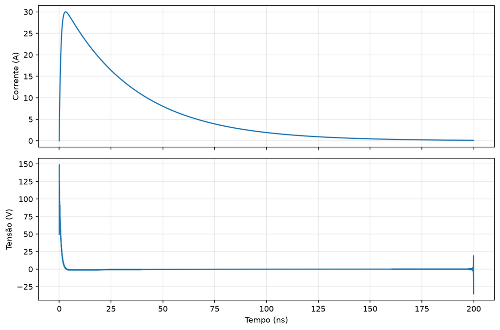

**Casos-limite:** com $L=0$, confirme $v(t)=Ri(t)$; com $R=0$, compare $v(t)$ a $L\,di/dt$. O pico negativo após a frente não é necessariamente uma falha numérica: decorre da derivada durante a cauda.

## 14.12 Laboratório Python — rede ABCD de filtro LC

PYTHON

```
import numpy as np
import matplotlib.pyplot as plt

f = np.logspace(3, 9, 1200)
w = 2*np.pi*f
Zs, Zl = 5.0, 20.0
L, rL, cp = 4.7e-6, 80e-3, 8e-12
C, esr, esl = 220e-9, 30e-3, 1.2e-9
Zseries = 1/(1/(rL + 1j*w*L) + 1j*w*cp)
Zcap = esr + 1j*w*esl + 1/(1j*w*C)
Yshunt = 1/Zcap

# Cascata: elemento série seguido de elemento shunt
A = 1 + Zseries*Yshunt
B = Zseries
Cmat = Yshunt
D = np.ones_like(f)
H = Zl/(A*Zl + B + Zs*(Cmat*Zl + D))
H0 = Zl/(Zs + Zl)
IL = 20*np.log10(np.abs(H0/H))

plt.semilogx(f, IL)
plt.axhline(0, color='k', lw=.8)
plt.xlabel('Frequência (Hz)'); plt.ylabel('Perda de inserção (dB)')
plt.title('Filtro LC real entre impedâncias não normalizadas')
plt.grid(True, which='both', alpha=.3); plt.tight_layout()
```

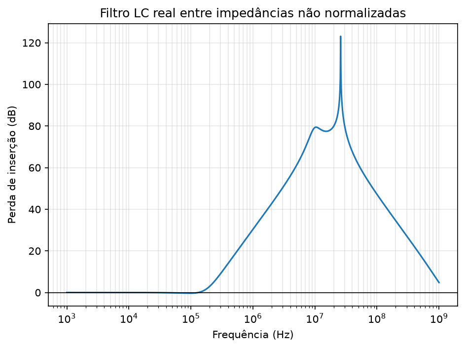

Varra $Z_S$ e $Z_L$. Regiões com perda de inserção negativa indicam amplificação por ressonância/mismatch, não criação de energia.

## 14.13 Sensibilidade e Monte Carlo

Para uma saída $y=g(x_1,\ldots,x_n)$, a sensibilidade normalizada local é

$$ S_{x_i}^{y}=\frac{x_i}{y}\frac{\partial y}{\partial x_i}. $$

Use derivadas locais para triagem e Monte Carlo quando tolerâncias, não linearidades ou distribuições tornarem a propagação linear inadequada. Reporte percentis e número de amostras; não apresente apenas a melhor curva.

## 14.14 Laboratório SPICE — injeção transitória e proteção

SPICE

```
* Pulso de corrente didatico em porta protegida
Iinj port 0 PWL(0 0 0.8n 30 5n 12 40n 2 150n 0)
Ltrace port clamp 3n
Rtrace port clamp 50m
Dprot clamp 0 DTVS
Cinput clamp 0 20p
Rinput clamp 0 100k
.model DTVS D(BV=6 IBV=1m RS=0.2 CJO=200p)
.tran 20p 200n 0 50p
.print tran v(port) v(clamp)
.end
```

**Output:**

```
Circuit: generated from textbook spice code block

Doing analysis at TEMP = 27.000000 and TNOM = 27.000000

Using SPARSE 1.3 as Direct Linear Solver

Initial Transient Solution
--------------------------

Node                                   Voltage
----                                   -------
port                              -9.27487e-26
clamp                             -9.27487e-26
ltrace#branch                                0

No. of Data Rows : 4025
                    generated from textbook spice code block
                    Transient Analysis  Tue Nov 10 17:51:35  2026
```

[output not shown]

[output not shown]

[output not shown]

[output not shown]

[output not shown]

[output not shown]

[output not shown]

[output not shown]

[output not shown]

[output not shown]

[output not shown]

[output not shown]

[output not shown]

[output not shown]

[output not shown]

[output not shown]

[output not shown]

[output not shown]

[output not shown]

[output not shown]

[output not shown]

[output not shown]

[output not shown]

[output not shown]

O modelo genérico não representa uma TVS comercial. Varra indutância da conexão e capacitância de junção; compare tensão na porta e no nó protegido. Verifique energia no dispositivo por integração de $v(t)i(t)$ quando o simulador oferecer medida adequada.

## 14.15 Entrega recomendada

Para cada modelo, entregue: pergunta, diagrama de portas, equações, parâmetros e fontes, faixa de validade, hipóteses, resultado, sensibilidade, validação e decisão. Código sem essa documentação não constitui um modelo auditável.